# Assignment 2

Author

RanZhu

## 0. Setup loading packages

```r
library(nycflights13)
library(dplyr)
library(ggplot2)
```

## Q1. Find the 10 Most Popular Destinations

```r
top_destinations <- flights |>
  group_by(dest) |>
  summarise(
    n_flights = n()
  ) |>
  arrange(desc(n_flights)) |>
  head(n = 10)

top_destinations
```

```
# A tibble: 10 × 2
   dest  n_flights
   <chr>     <int>
 1 ORD       17283
 2 ATL       17215
 3 LAX       16174
 4 BOS       15508
 5 MCO       14082
 6 CLT       14064
 7 SFO       13331
 8 FLL       12055
 9 MIA       11728
10 DCA        9705
```

After grouping the data by `dest` and sorting the flight counts from highest to lowest, the top 10 most popular destinations were ORD, with 17,283 flights; ATL, with 17,215 flights; LAX, with 16,174 flights; BOS, with 15,508 flights; MCO, with 14,082 flights; CLT, with 14,064 flights; SFO, with 13,331 flights; FLL, with 12,055 flights; MIA, with 11,728 flights; and DCA, with 9,705 flights.

## Q2. Create New Categorical Variables and Barplots

### 1. create two categorical variables

```r
flights <- flights |>
  mutate(
    dep_period = ifelse(
      is.na(dep_time), NA,
      ifelse(
        dep_time < 600 | dep_time == 2400, "early morning",
        ifelse(
          dep_time < 1200, "morning",
          ifelse(dep_time < 1800, "afternoon", "evening")
        )
      )
    ),
    arr_period = ifelse(
      is.na(arr_time), NA,
      ifelse(
        arr_time < 600 | arr_time == 2400, "early morning",
        ifelse(
          arr_time < 1200, "morning",
          ifelse(arr_time < 1800, "afternoon", "evening")
        )
      )
    )
  )
```

```r
flights <- flights |>
  mutate(
    dep_period = factor(
      dep_period,
      levels = c("early morning", "morning", "afternoon", "evening")
    ),
    arr_period = factor(
      arr_period,
      levels = c("early morning", "morning", "afternoon", "evening")
    )
  )
```

### 2. Departure time barplot

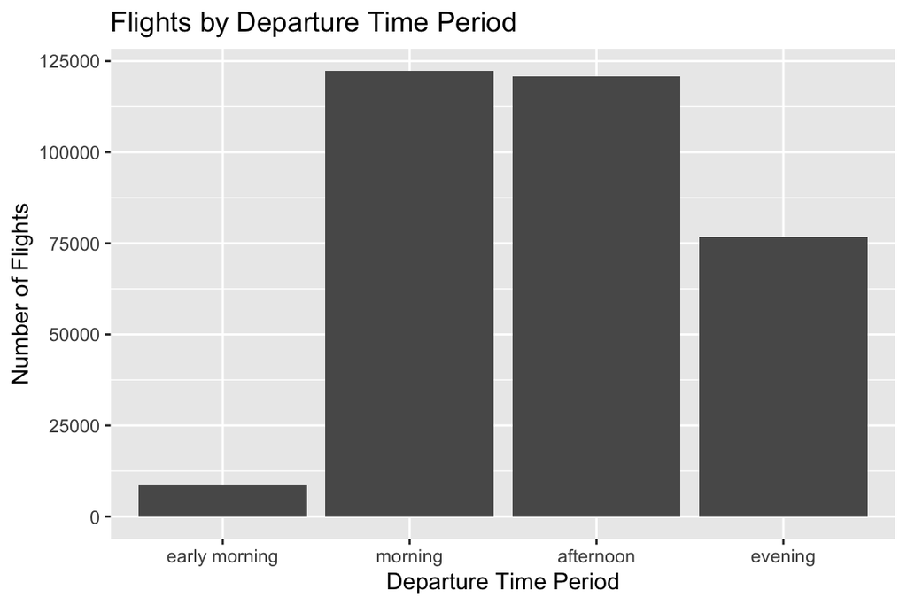

```r
flights |>
  filter(!is.na(dep_period)) |>
  ggplot(mapping = aes(x = dep_period)) +
  geom_bar() +
  labs(
    title = "Flights by Departure Time Period",
    x = "Departure Time Period",
    y = "Number of Flights"
  )
```

### 3. Arrival time barplot

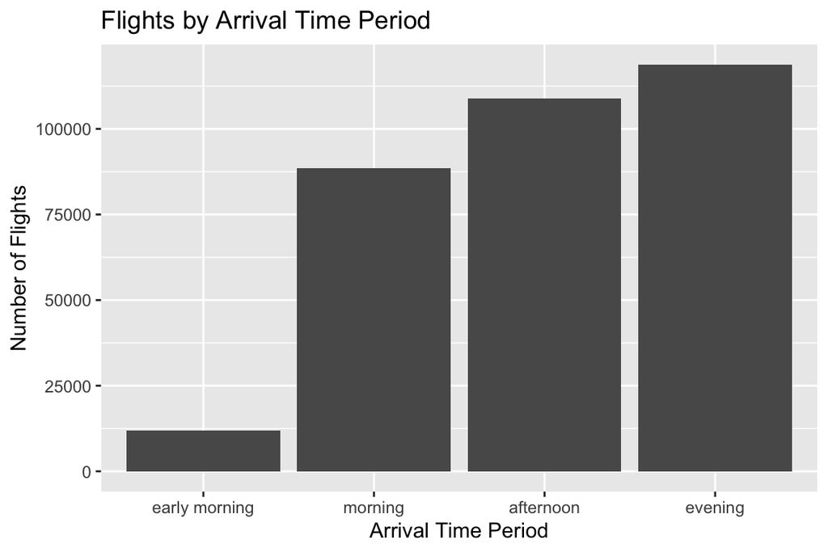

```r
flights |>
  filter(!is.na(arr_period)) |>
  ggplot(mapping = aes(x = arr_period)) +
  geom_bar() +
  labs(
    title = "Flights by Arrival Time Period",
    x = "Arrival Time Period",
    y = "Number of Flights"
  )
```

### 4. Calculate red-eye flights percentage

```r
flights_with_times <- flights |>
  filter(!is.na(dep_period) & !is.na(arr_period))
```

```r
red_eye_flights <- flights_with_times |>
  filter(
    (dep_period == "afternoon" | dep_period == "evening") &
      (arr_period == "early morning" | arr_period == "morning")
  )
```

```r
red_eye_percentage <- nrow(red_eye_flights) /
  nrow(flights_with_times) * 100

red_eye_percentage
```

```
[1] 3.278029
```

I divided the departure and arrival times into four categories using the time intervals specified in the question. The four categories were “early morning”, “morning”, “afternoon”, and “evening”. Flights with missing departure or arrival times were left as missing because their actual time periods could not be determined. In the departure-time barplot, morning had the tallest bar, followed closely by afternoon. Evening had fewer departures, and early morning had the shortest bar. This shows that departures were concentrated in the morning and afternoon, while relatively few flights departed in the early morning.

In the arrival-time barplot, evening had the tallest bar, followed by afternoon and morning. Early morning again had the shortest bar. Therefore, arrivals were most commonly recorded in the evening and least commonly recorded in the early morning. Overall, early morning was the least common time period in both plots.

I classified a flight as a red-eye flight if it departed in the afternoon or evening and arrived in the early morning or morning. Among flights with non-missing departure and arrival times, approximately 3.28% were classified as red-eye flights.

## Q3. Planes That Flew for Multiple Airlines

### 1. keep only unique plane-airline combinations

```r
plane_airlines <- unique(
  flights[, c("tailnum", "carrier")]
)

plane_airlines <- plane_airlines[
  !is.na(plane_airlines$tailnum),
]
```

### 2. Identify planes that flew for multiple Airlines

```r
multi_airline_planes <- plane_airlines |>
  group_by(tailnum) |>
  summarise(
    n_airlines = n()
  ) |>
  filter(n_airlines > 1) |>
  arrange(tailnum)

multi_airline_planes
```

```
# A tibble: 17 × 2
   tailnum n_airlines
   <chr>        <int>
 1 N146PQ           2
 2 N153PQ           2
 3 N176PQ           2
 4 N181PQ           2
 5 N197PQ           2
 6 N200PQ           2
 7 N228PQ           2
 8 N232PQ           2
 9 N933AT           2
10 N935AT           2
11 N977AT           2
12 N978AT           2
13 N979AT           2
14 N981AT           2
15 N989AT           2
16 N990AT           2
17 N994AT           2
```

### 3. calculate the number of planes

```r
nrow(multi_airline_planes)
```

```
[1] 17
```

### 4. Identify the Airlines for each plane

```r
multi_airline_details <- merge(
  x = multi_airline_planes,
  y = plane_airlines,
  by = "tailnum",
  all.x = TRUE,
  all.y = FALSE
)
```

```r
multi_airline_details <- merge(
  x = multi_airline_details,
  y = airlines,
  by = "carrier",
  all.x = TRUE,
  all.y = FALSE
)

multi_airline_details <- multi_airline_details |>
  arrange(tailnum, carrier)

multi_airline_details
```

```
   carrier tailnum n_airlines                        name
1       9E  N146PQ          2           Endeavor Air Inc.
2       EV  N146PQ          2    ExpressJet Airlines Inc.
3       9E  N153PQ          2           Endeavor Air Inc.
4       EV  N153PQ          2    ExpressJet Airlines Inc.
5       9E  N176PQ          2           Endeavor Air Inc.
6       EV  N176PQ          2    ExpressJet Airlines Inc.
7       9E  N181PQ          2           Endeavor Air Inc.
8       EV  N181PQ          2    ExpressJet Airlines Inc.
9       9E  N197PQ          2           Endeavor Air Inc.
10      EV  N197PQ          2    ExpressJet Airlines Inc.
11      9E  N200PQ          2           Endeavor Air Inc.
12      EV  N200PQ          2    ExpressJet Airlines Inc.
13      9E  N228PQ          2           Endeavor Air Inc.
14      EV  N228PQ          2    ExpressJet Airlines Inc.
```

[output cut: 20 more lines]

```r
unique(
  multi_airline_details[, c("carrier", "name")]
)
```

```
   carrier                        name
1       9E           Endeavor Air Inc.
2       EV    ExpressJet Airlines Inc.
17      DL        Delta Air Lines Inc.
18      FL AirTran Airways Corporation
```

In step 1, I removed missing tail numbers and kept only the unique `tailnum` and `carrier` combinations so that the same plane-airline combination was counted only once. In step 2, I grouped the data by `tailnum` and retained planes that appeared under more than one carrier. The resulting table showed an `n_airlines` value of 2 for every selected plane.

In step 3, I counted the rows in this table and found 17 planes. Therefore, 17 planes flew for multiple airlines, and each of them flew for exactly two airlines. In step 4, I merged the results with the `airlines` data to obtain the full airline names. Eight planes had flight records under both Endeavor Air Inc. (9E) and ExpressJet Airlines Inc. (EV). These planes were N146PQ, N153PQ, N176PQ, N181PQ, N197PQ, N200PQ, N228PQ, and N232PQ. The other nine planes had flight records under both Delta Air Lines Inc. (DL) and AirTran Airways Corporation (FL). These planes were N933AT, N935AT, N977AT, N978AT, N979AT, N981AT, N989AT, N990AT, and N994AT.

## Q4. What is the missing relationship? How should it appear in the diagram?

The missing relationship is between `origin` in the `weather` data and `faa` in the `airports` data. The `airports` data contains one row for each airport, and `faa` is the airport code used to identify that airport. The `weather` data contains multiple hourly weather observations for each airport, and `origin` records the airport where each observation was made. For example, the `weather` data can contain many rows with `origin = "LGA"` because the weather was measured at LGA during many different hours. All of these rows correspond to the single airport record with `faa = "LGA"` in the `airports` data. Therefore, this is a many-to-one relationship because many weather observations correspond to one airport. In the diagram, an arrow should connect `origin` in `weather` to `faa` in `airports`.

## Q5. Prepare the Merged Flights and Weather Data

### 1. Create a combined weather variable

```r
weather <- weather |>
  mutate(
    weather_id = paste(
      year,
      month,
      day,
      hour,
      origin,
      sep = "_"
    )
  )
```

### 2. Count the duplicated values

```r
sum(duplicated(weather$weather_id))
```

```
[1] 3
```

### 3. Identify the duplicated records

```r
duplicate_weather <- weather |>
  group_by(weather_id) |>
  filter(n() > 1) |>
  select(
    weather_id,
    year,
    month,
    day,
    hour,
    origin,
    time_hour
  ) |>
  arrange(origin, time_hour)

duplicate_weather
```

```
# A tibble: 6 × 7
# Groups:   weather_id [3]
  weather_id       year month   day  hour origin time_hour
  <chr>           <int> <int> <int> <int> <chr>  <dttm>
1 2013_11_3_1_EWR  2013    11     3     1 EWR    2013-11-03 01:00:00
2 2013_11_3_1_EWR  2013    11     3     1 EWR    2013-11-03 01:00:00
3 2013_11_3_1_JFK  2013    11     3     1 JFK    2013-11-03 01:00:00
4 2013_11_3_1_JFK  2013    11     3     1 JFK    2013-11-03 01:00:00
5 2013_11_3_1_LGA  2013    11     3     1 LGA    2013-11-03 01:00:00
6 2013_11_3_1_LGA  2013    11     3     1 LGA    2013-11-03 01:00:00
```

```r
sum(
  duplicated(
    weather[, c("origin", "time_hour")]
  )
)
```

```
[1] 0
```

### 4. Merge the Flights and Weather Data

```r
weather_for_merge <- weather |>
  select(
    origin,
    time_hour,
    temp,
    dewp,
    humid,
    wind_dir,
    wind_speed,
    wind_gust,
    precip,
    pressure,
    visib
  )
```

```r
flights_weather <- merge(
  x = flights,
  y = weather_for_merge,
  by = c("origin", "time_hour"),
  all.x = TRUE,
  all.y = FALSE
)
```

```r
nrow(flights)
```

```
[1] 336776
```

```r
nrow(flights_weather)
```

```
[1] 336776
```

```r
flights_weather |>
  select(
    origin,
    time_hour,
    carrier,
    flight,
    sched_dep_time,
    temp,
    dewp,
    humid,
    wind_speed,
    precip,
    visib
  ) |>
  head()
```

```
  origin           time_hour carrier flight sched_dep_time  temp  dewp humid
1    EWR 2013-01-01 05:00:00      UA   1545            515 39.02 28.04 64.43
2    EWR 2013-01-01 05:00:00      UA   1696            558 39.02 28.04 64.43
3    EWR 2013-01-01 06:00:00      UA   1111            645 37.94 28.04 67.21
4    EWR 2013-01-01 06:00:00      US   1019            630 37.94 28.04 67.21
5    EWR 2013-01-01 06:00:00      EV   4626            630 37.94 28.04 67.21
6    EWR 2013-01-01 06:00:00      UA    556            646 37.94 28.04 67.21
  wind_speed precip visib
1   12.65858      0    10
2   12.65858      0    10
3   11.50780      0    10
4   11.50780      0    10
5   11.50780      0    10
6   11.50780      0    10
```

I created `weather_id` by combining `year`, `month`, `day`, `hour`, and `origin`. The result showed three duplicated values. The duplicate table contained six rows because each duplicated value appeared twice. These duplicated records occurred at 1:00 a.m. on November 3, 2013, at EWR, JFK, and LGA. This occurred because daylight saving time ended on that date, causing the hour from 1:00 a.m. to 2:00 a.m. to occur twice. The two occurrences had the same year, month, day, hour, and origin, so `weather_id` could not distinguish between them. However, when I checked the combination of `origin` and `time_hour`, the number of duplicates was zero. This shows that `time_hour` distinguishes the two occurrences of 1:00 a.m. and that `origin` and `time_hour` together uniquely identify the weather observations.

I then merged the `flights` and `weather` data using `origin` and `time_hour`. The `origin` variable matched each flight with weather information from its departure airport, while `time_hour` matched the weather to the hour of its scheduled departure. I used `all.x = TRUE` to retain all flights in the merged dataset. Both the original `flights` data and the merged `flights_weather` data contained 336,776 rows, showing that all flight records were retained. The resulting dataset contains each flight together with the weather measurements recorded at its departure airport during its scheduled departure hour.

## Q6. Perform steps 2-5 of the EDA checklist

### 2. Check the size of the data

```r
dim(flights_weather)
```

```
[1] 336776     30
```

```r
nrow(flights_weather)
```

```
[1] 336776
```

```r
ncol(flights_weather)
```

```
[1] 30
```

The merged dataset contained 336,776 observations and 30 variables. Each observation represents one flight and includes its flight information and the weather measurements at its departure airport during its scheduled departure hour.

### 3. Examine the variables and their types

```r
str(flights_weather)
```

```
'data.frame':   336776 obs. of  30 variables:
 $ origin        : chr  "EWR" "EWR" "EWR" "EWR" ...
 $ time_hour     : POSIXct, format: "2013-01-01 05:00:00" "2013-01-01 05:00:00" ...
 $ year          : int  2013 2013 2013 2013 2013 2013 2013 2013 2013 2013 ...
 $ month         : int  1 1 1 1 1 1 1 1 1 1 ...
 $ day           : int  1 1 1 1 1 1 1 1 1 1 ...
 $ dep_time      : int  517 554 732 629 624 643 644 643 601 559 ...
 $ sched_dep_time: int  515 558 645 630 630 646 636 645 600 600 ...
 $ dep_delay     : num  2 -4 47 -1 -6 -3 8 -2 1 -1 ...
 $ arr_time      : int  830 740 1011 824 909 922 931 837 844 854 ...
 $ sched_arr_time: int  819 728 941 833 840 940 940 848 850 902 ...
 $ arr_delay     : num  11 12 30 -9 29 -18 -9 -11 -6 -8 ...
 $ carrier       : chr  "UA" "UA" "UA" "US" ...
 $ flight        : int  1545 1696 1111 1019 4626 556 1701 926 343 1187 ...
 $ tailnum       : chr  "N14228" "N39463" "N37456" "N426US" ...
```

[output cut: 16 more lines]

The `str()` output showed that `origin`, `carrier`, `tailnum`, and `dest` were character variables, while `time_hour` was a date-time variable. The `dep_period` and `arr_period` variables were factors with four levels, and the delay and weather measurements were numeric variables.

### 4. Look at the top and bottom of the data

```r
head(flights_weather)
```

```
  origin           time_hour year month day dep_time sched_dep_time dep_delay
1    EWR 2013-01-01 05:00:00 2013     1   1      517            515         2
2    EWR 2013-01-01 05:00:00 2013     1   1      554            558        -4
3    EWR 2013-01-01 06:00:00 2013     1   1      732            645        47
4    EWR 2013-01-01 06:00:00 2013     1   1      629            630        -1
5    EWR 2013-01-01 06:00:00 2013     1   1      624            630        -6
6    EWR 2013-01-01 06:00:00 2013     1   1      643            646        -3
  arr_time sched_arr_time arr_delay carrier flight tailnum dest air_time
1      830            819        11      UA   1545  N14228  IAH      227
2      740            728        12      UA   1696  N39463  ORD      150
3     1011            941        30      UA   1111  N37456  MCO      145
4      824            833        -9      US   1019  N426US  CLT       91
5      909            840        29      EV   4626  N11107  MSP      190
6      922            940       -18      UA    556  N497UA  PBI      146
  distance hour minute    dep_period arr_period  temp  dewp humid wind_dir
1     1400    5     15 early morning    morning 39.02 28.04 64.43      260
2      719    5     58 early morning    morning 39.02 28.04 64.43      260
3      937    6     45       morning    morning 37.94 28.04 67.21      240
4      529    6     30       morning    morning 37.94 28.04 67.21      240
5     1008    6     30       morning    morning 37.94 28.04 67.21      240
6     1023    6     46       morning    morning 37.94 28.04 67.21      240
  wind_speed wind_gust precip pressure visib
1   12.65858        NA      0   1011.9    10
2   12.65858        NA      0   1011.9    10
3   11.50780        NA      0   1012.4    10
4   11.50780        NA      0   1012.4    10
5   11.50780        NA      0   1012.4    10
6   11.50780        NA      0   1012.4    10
```

```r
tail(flights_weather)
```

```
       origin           time_hour year month day dep_time sched_dep_time
336771    LGA 2013-12-31 19:00:00 2013    12  31     1952           1945
336772    LGA 2013-12-31 19:00:00 2013    12  31     2022           1940
336773    LGA 2013-12-31 20:00:00 2013    12  31     2019           2033
336774    LGA 2013-12-31 20:00:00 2013    12  31       NA           2025
336775    LGA 2013-12-31 21:00:00 2013    12  31     2054           2101
336776    LGA 2013-12-31 21:00:00 2013    12  31     2132           2130
       dep_delay arr_time sched_arr_time arr_delay carrier flight tailnum dest
336771         7     2148           2150        -2      MQ   3603  N5PBMQ  DTW
336772        42     2323           2243        40      B6   1271  N661JB  FLL
336773       -14     2144           2206       -22      FL   1544  N974AT  CAK
336774        NA       NA           2205        NA      AA    371  N482AA  ORD
336775        -7       22           2346        36      B6    499  N563JB  MCO
336776         2       41             18        23      B6   1371  N599JB  FLL
       air_time distance hour minute dep_period    arr_period temp dewp humid
336771       89      502   19     45    evening       evening   NA   NA    NA
336772      166     1076   19     40    evening       evening   NA   NA    NA
336773       74      397   20     33    evening       evening   NA   NA    NA
336774       NA      733   20     25       <NA>          <NA>   NA   NA    NA
336775      154      950   21      1    evening early morning   NA   NA    NA
336776      160     1076   21     30    evening early morning   NA   NA    NA
       wind_dir wind_speed wind_gust precip pressure visib
336771       NA         NA        NA     NA       NA    NA
336772       NA         NA        NA     NA       NA    NA
336773       NA         NA        NA     NA       NA    NA
336774       NA         NA        NA     NA       NA    NA
336775       NA         NA        NA     NA       NA    NA
336776       NA         NA        NA     NA       NA    NA
```

The first six rows showed flights from EWR on January 1, 2013, and the last six rows showed flights from LGA on December 31, 2013. I also noticed that one of the last six flights had a missing value for `dep_time`.

### 5. Visualize the distributions of key variables

```r
summary(
  flights_weather[, c(
    "dep_delay",
    "arr_delay",
    "temp",
    "dewp",
    "humid",
    "wind_dir",
    "wind_speed",
    "wind_gust",
    "precip",
    "pressure",
    "visib"
  )]
)
```

```
   dep_delay         arr_delay             temp             dewp
 Min.   : -43.00   Min.   : -86.000   Min.   : 10.94   Min.   :-9.94
 1st Qu.:  -5.00   1st Qu.: -17.000   1st Qu.: 42.08   1st Qu.:26.06
 Median :  -2.00   Median :  -5.000   Median : 57.20   Median :42.80
 Mean   :  12.64   Mean   :   6.895   Mean   : 57.00   Mean   :41.63
 3rd Qu.:  11.00   3rd Qu.:  14.000   3rd Qu.: 71.96   3rd Qu.:57.92
 Max.   :1301.00   Max.   :1272.000   Max.   :100.04   Max.   :78.08
 NAs    :8255      NAs    :9430       NAs    :1573     NAs    :1573
     humid           wind_dir       wind_speed       wind_gust
 Min.   : 12.74   Min.   :  0.0   Min.   : 0.000   Min.   :16.11
 1st Qu.: 43.99   1st Qu.:130.0   1st Qu.: 6.905   1st Qu.:20.71
 Median : 57.73   Median :220.0   Median :10.357   Median :24.17
 Mean   : 59.56   Mean   :201.5   Mean   :11.114   Mean   :25.25
 3rd Qu.: 75.33   3rd Qu.:290.0   3rd Qu.:14.960   3rd Qu.:28.77
 Max.   :100.00   Max.   :360.0   Max.   :42.579   Max.   :66.75
 NAs    :1573     NAs    :9796    NAs    :1634     NAs    :256391
     precip            pressure          visib
 Min.   :0.000000   Min.   : 983.8   Min.   : 0.000
 1st Qu.:0.000000   1st Qu.:1012.7   1st Qu.:10.000
 Median :0.000000   Median :1017.5   Median :10.000
 Mean   :0.004564   Mean   :1017.8   Mean   : 9.256
 3rd Qu.:0.000000   3rd Qu.:1022.8   3rd Qu.:10.000
 Max.   :1.210000   Max.   :1042.1   Max.   :10.000
 NAs    :1556       NAs    :38788    NAs    :1556
```

#### Delay Variables

```r
sum(is.na(flights_weather$dep_delay))
```

```
[1] 8255
```

```r
mean(is.na(flights_weather$dep_delay)) * 100
```

```
[1] 2.451184
```

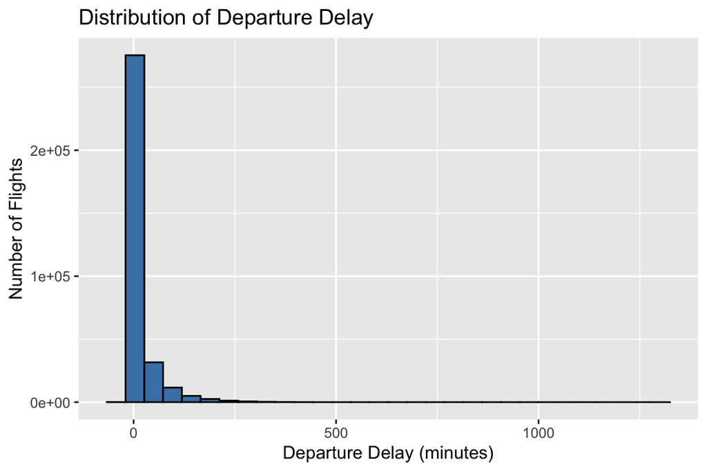

```r
ggplot(flights_weather, aes(x = dep_delay)) +
  geom_histogram(
    bins = 30,
    color = "black",
    fill = "steelblue",
    na.rm = TRUE
  ) +
  labs(
    title = "Distribution of Departure Delay",
    x = "Departure Delay (minutes)",
    y = "Number of Flights"
  )
```

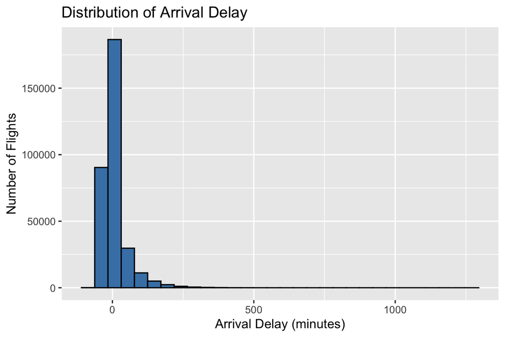

```r
ggplot(flights_weather, aes(x = arr_delay)) +
  geom_histogram(
    bins = 30,
    color = "black",
    fill = "steelblue",
    na.rm = TRUE
  ) +
  labs(
    title = "Distribution of Arrival Delay",
    x = "Arrival Delay (minutes)",
    y = "Number of Flights"
  )
```

The histograms showed that both departure and arrival delays were strongly right-skewed. Most flights were concentrated near zero, while a much smaller number formed long tails toward larger delays. The summary statistics showed that the maximum departure delay was 1,301 minutes and the maximum arrival delay was 1,272 minutes. The mean departure delay was 12.64 minutes, compared with a median of −2 minutes. Similarly, the mean arrival delay was 6.90 minutes, while the median was −5 minutes. The histograms excluded 8,255 missing departure-delay values and 9,430 missing arrival-delay values.

#### Temperature and Moisture Variables

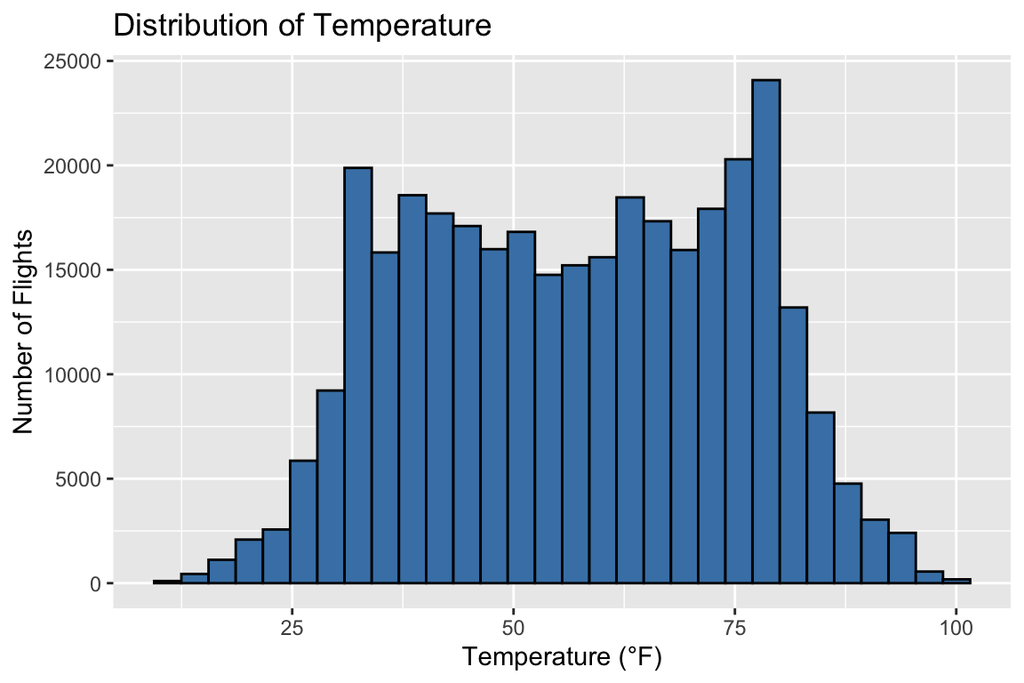

```r
ggplot(flights_weather, aes(x = temp)) +
  geom_histogram(
    bins = 30,
    color = "black",
    fill = "steelblue",
    na.rm = TRUE
  ) +
  labs(
    title = "Distribution of Temperature",
    x = "Temperature (°F)",
    y = "Number of Flights"
  )
```

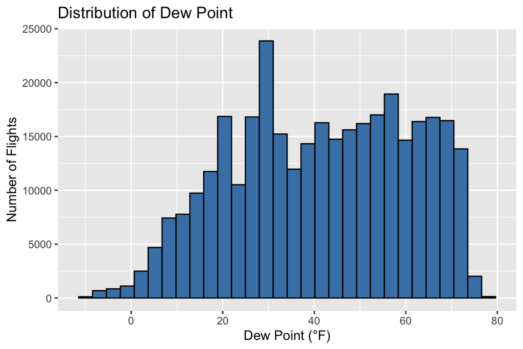

```r
ggplot(flights_weather, aes(x = dewp)) +
  geom_histogram(
    bins = 30,
    color = "black",
    fill = "steelblue",
    na.rm = TRUE
  ) +
  labs(
    title = "Distribution of Dew Point",
    x = "Dew Point (°F)",
    y = "Number of Flights"
  )
```

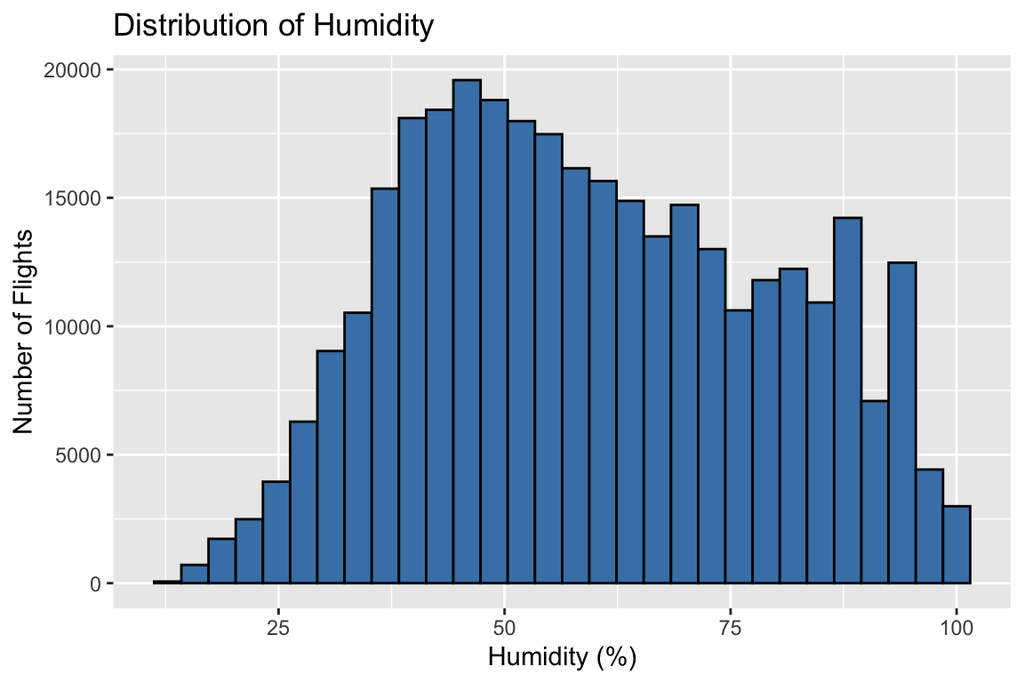

```r
ggplot(flights_weather, aes(x = humid)) +
  geom_histogram(
    bins = 30,
    color = "black",
    fill = "steelblue",
    na.rm = TRUE
  ) +
  labs(
    title = "Distribution of Humidity",
    x = "Humidity (%)",
    y = "Number of Flights"
  )
```

The summary statistics showed that temperature ranged from 10.94°F to 100.04°F, with a mean of 57.00°F and a median of 57.20°F. The histogram showed a broad distribution, with visible concentrations around the low 30s and upper 70s. Dew point ranged from −9.94°F to 78.08°F, and most of its observations appeared between approximately 20°F and 70°F. Humidity ranged from 12.74% to 100%, with the largest concentration around 40% to 60%. Each of these three variables had 1,573 missing observations.

#### Wind Variables

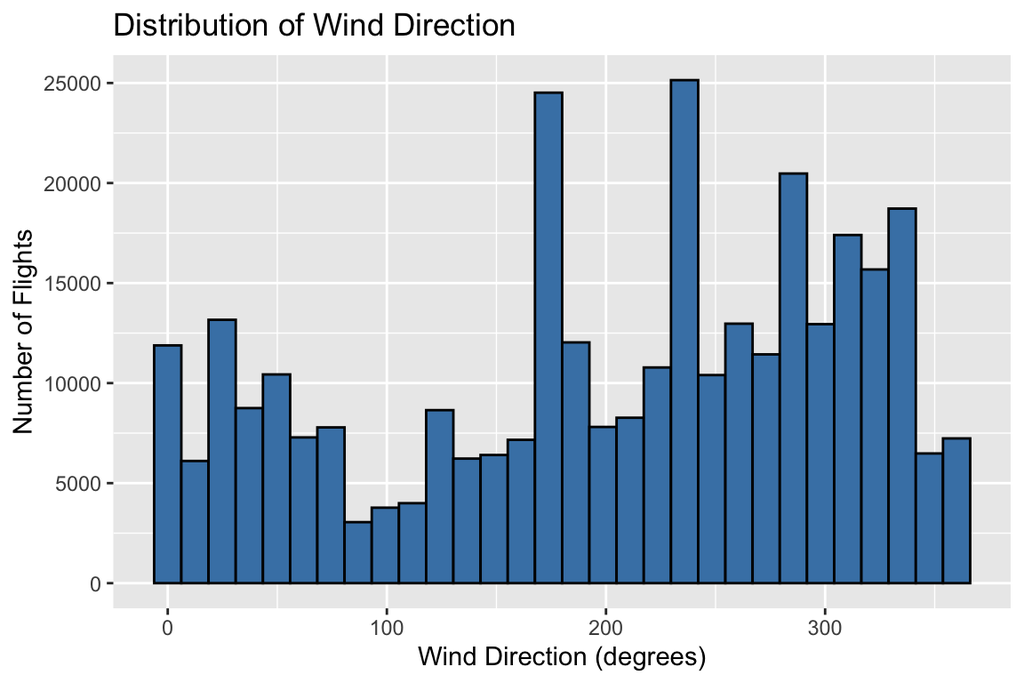

```r
ggplot(flights_weather, aes(x = wind_dir)) +
  geom_histogram(
    bins = 30,
    color = "black",
    fill = "steelblue",
    na.rm = TRUE
  ) +
  labs(
    title = "Distribution of Wind Direction",
    x = "Wind Direction (degrees)",
    y = "Number of Flights"
  )
```

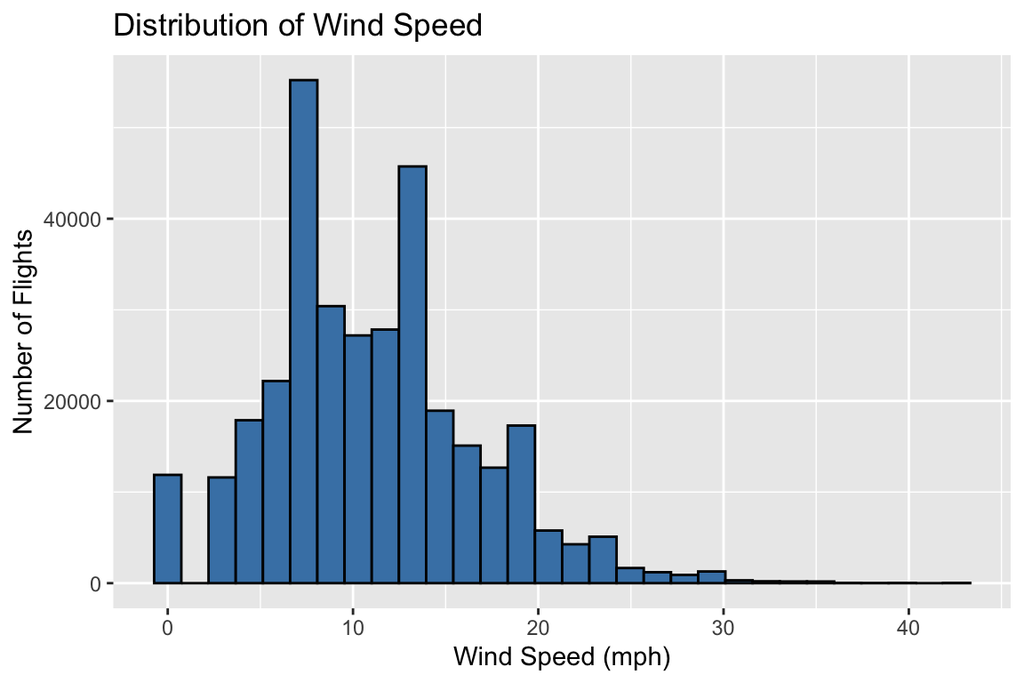

```r
ggplot(flights_weather, aes(x = wind_speed)) +
  geom_histogram(
    bins = 30,
    color = "black",
    fill = "steelblue",
    na.rm = TRUE
  ) +
  labs(
    title = "Distribution of Wind Speed",
    x = "Wind Speed (mph)",
    y = "Number of Flights"
  )
```

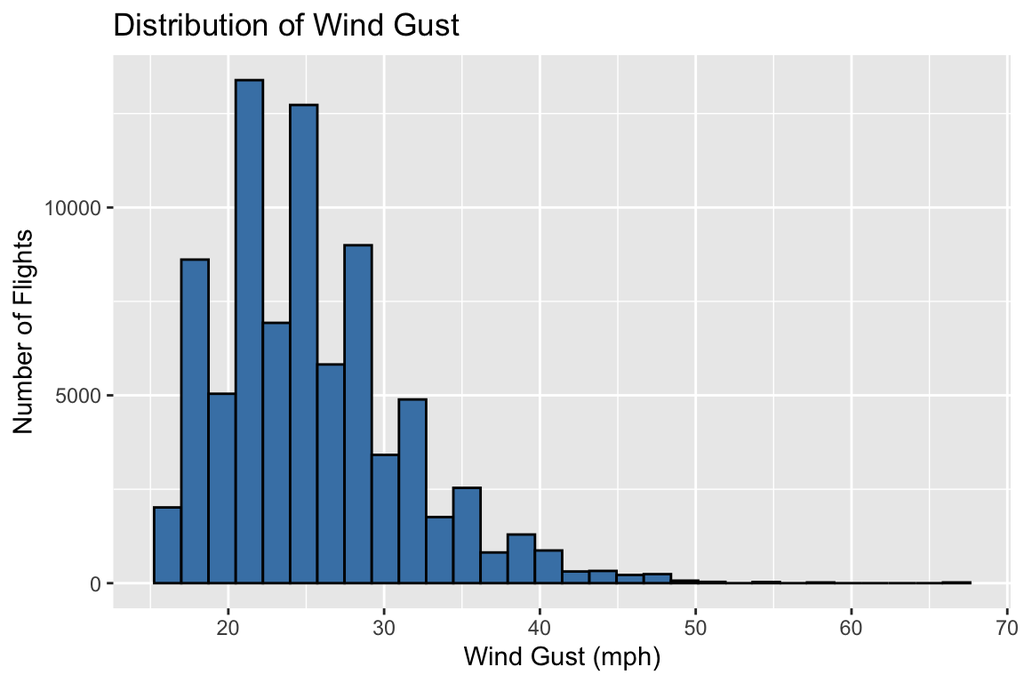

```r
ggplot(flights_weather, aes(x = wind_gust)) +
  geom_histogram(
    bins = 30,
    color = "black",
    fill = "steelblue",
    na.rm = TRUE
  ) +
  labs(
    title = "Distribution of Wind Gust",
    x = "Wind Gust (mph)",
    y = "Number of Flights"
  )
```

The summary statistics showed that wind direction ranged from 0° to 360°. Its histogram was not evenly distributed, with the most prominent bars around 170° to 180° and 230° to 240°. The wind-speed histogram was right-skewed, with most observations below 20 mph, while the summary statistics showed a maximum of 42.58 mph. Wind gust was also right-skewed, with most recorded values between approximately 18 and 30 mph and a maximum of 66.75 mph. The summary also showed that `wind_gust` had 256,391 missing observations, so its histogram was based on a much smaller subset of the data.

#### Other Weather Variables

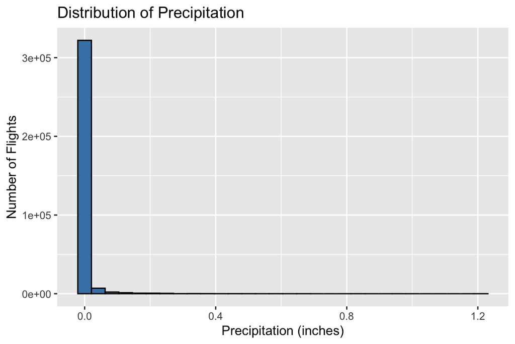

```r
ggplot(flights_weather, aes(x = precip)) +
  geom_histogram(
    bins = 30,
    color = "black",
    fill = "steelblue",
    na.rm = TRUE
  ) +
  labs(
    title = "Distribution of Precipitation",
    x = "Precipitation (inches)",
    y = "Number of Flights"
  )
```

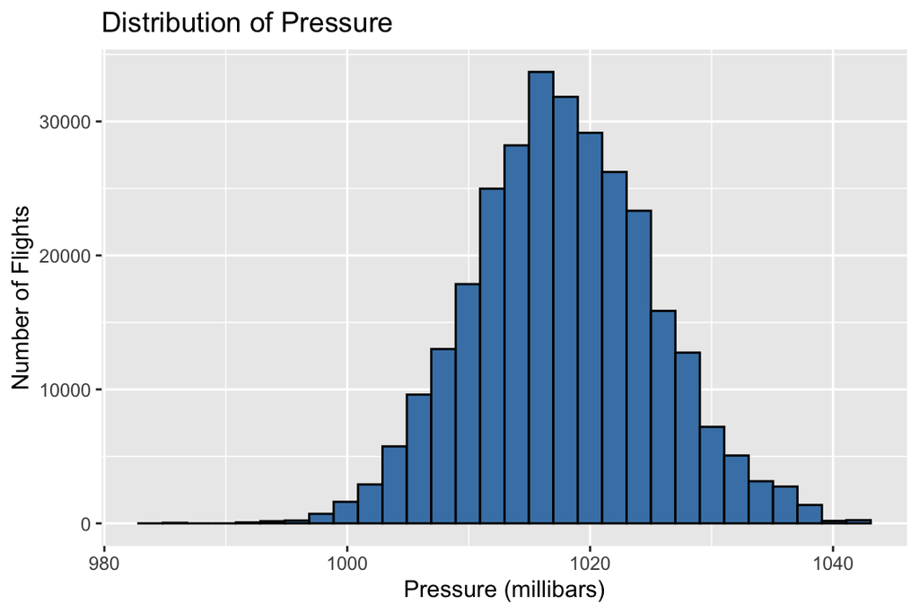

```r
ggplot(flights_weather, aes(x = pressure)) +
  geom_histogram(
    bins = 30,
    color = "black",
    fill = "steelblue",
    na.rm = TRUE
  ) +
  labs(
    title = "Distribution of Pressure",
    x = "Pressure (millibars)",
    y = "Number of Flights"
  )
```

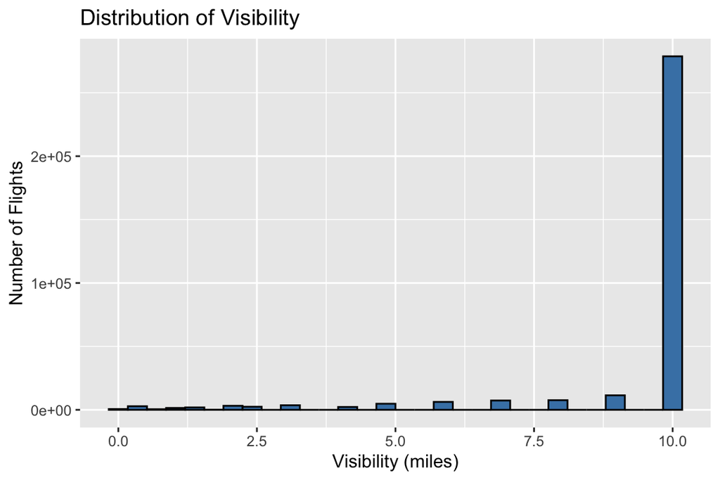

```r
ggplot(flights_weather, aes(x = visib)) +
  geom_histogram(
    bins = 30,
    color = "black",
    fill = "steelblue",
    na.rm = TRUE
  ) +
  labs(
    title = "Distribution of Visibility",
    x = "Visibility (miles)",
    y = "Number of Flights"
  )
```

The precipitation histogram showed that observations were heavily concentrated at zero, with a small number of positive values forming a long right tail. The `summary()` output showed that the first quartile, median, and third quartile were all 0 inches, while the maximum was 1.21 inches. Pressure had a roughly bell-shaped distribution centered near 1,018 millibars. Its mean was 1,017.8 millibars, and its median was 1,017.5 millibars. Visibility was strongly concentrated at 10 miles, and the `summary()` output showed that its first quartile, median, and third quartile were all 10 miles. Values below 10 miles appeared much less frequently in the histogram.

## Q7. Average Departure Delays by Day, Airport, and Hour

### 1. Average departure delay by day. Which day had the worst average length of delay for departures?

```r
daily_departure_delays <- flights_weather |>
  group_by(year, month, day) |>
  summarise(
    avg_dep_delay = mean(dep_delay, na.rm = TRUE)
  )
```

```
`summarise()` has regrouped the output.
ℹ Summaries were computed grouped by year, month, and day.
ℹ Output is grouped by year and month.
ℹ Use `summarise(.groups = "drop_last")` to silence this message.
ℹ Use `summarise(.by = c(year, month, day))` for per-operation grouping
  (`?dplyr::dplyr_by`) instead.
```

```r
daily_departure_delays
```

```
# A tibble: 365 × 4
# Groups:   year, month [12]
    year month   day avg_dep_delay
   <int> <int> <int>         <dbl>
 1  2013     1     1         11.5
 2  2013     1     2         13.9
 3  2013     1     3         11.0
 4  2013     1     4          8.95
 5  2013     1     5          5.73
 6  2013     1     6          7.15
 7  2013     1     7          5.42
 8  2013     1     8          2.55
 9  2013     1     9          2.28
10  2013     1    10          2.84
# ℹ 355 more rows
```

```r
worst_delay_day <- daily_departure_delays |>
  arrange(desc(avg_dep_delay)) |>
  head(n = 1)

worst_delay_day
```

```
# A tibble: 1 × 4
# Groups:   year, month [1]
   year month   day avg_dep_delay
  <int> <int> <int>         <dbl>
1  2013     3     8          83.5
```

I grouped the flights by `year`, `month`, and `day` so that each group represented one calendar day, and then calculated the mean departure delay after removing missing values. After sorting the daily averages from highest to lowest, March 8, 2013 had the worst average departure delay at 83.54 minutes.

### 2. Average departure delay by day and origin. Which airport had the worst single day for delays and when was it?

```r
daily_origin_delays <- flights_weather |>
  group_by(year, month, day, origin) |>
  summarise(
    avg_dep_delay = mean(dep_delay, na.rm = TRUE)
  )
```

```
`summarise()` has regrouped the output.
ℹ Summaries were computed grouped by year, month, day, and origin.
ℹ Output is grouped by year, month, and day.
ℹ Use `summarise(.groups = "drop_last")` to silence this message.
ℹ Use `summarise(.by = c(year, month, day, origin))` for per-operation grouping
  (`?dplyr::dplyr_by`) instead.
```

```r
head(daily_origin_delays)
```

```
# A tibble: 6 × 5
# Groups:   year, month, day [2]
   year month   day origin avg_dep_delay
  <int> <int> <int> <chr>          <dbl>
1  2013     1     1 EWR            17.5
2  2013     1     1 JFK            12.2
3  2013     1     1 LGA             3.13
4  2013     1     2 EWR            25.3
5  2013     1     2 JFK             8.14
6  2013     1     2 LGA             6.06
```

```r
worst_airport_day <- daily_origin_delays |>
  arrange(desc(avg_dep_delay)) |>
  head(n = 1)

worst_airport_day
```

```
# A tibble: 1 × 5
# Groups:   year, month, day [1]
   year month   day origin avg_dep_delay
  <int> <int> <int> <chr>          <dbl>
1  2013     3     8 LGA             106.
```

I then added `origin` to the grouping variables to calculate the daily average separately for each airport. The highest airport-specific daily average occurred at LGA on March 8, 2013, when the average departure delay was 105.72 minutes.

### 3. Average departure delay by hour and origin. Which airport had the worst single hour for delays (and when was it)?

```r
hourly_origin_delays <- flights_weather |>
  group_by(year, month, day, hour, origin) |>
  summarise(
    avg_dep_delay = mean(dep_delay, na.rm = TRUE)
  )
```

```
`summarise()` has regrouped the output.
ℹ Summaries were computed grouped by year, month, day, hour, and origin.
ℹ Output is grouped by year, month, day, and hour.
ℹ Use `summarise(.groups = "drop_last")` to silence this message.
ℹ Use `summarise(.by = c(year, month, day, hour, origin))` for per-operation
  grouping (`?dplyr::dplyr_by`) instead.
```

```r
head(hourly_origin_delays)
```

```
# A tibble: 6 × 6
# Groups:   year, month, day, hour [2]
   year month   day  hour origin avg_dep_delay
  <int> <int> <int> <dbl> <chr>          <dbl>
1  2013     1     1     5 EWR           -1
2  2013     1     1     5 JFK            0.333
3  2013     1     1     5 LGA            4
4  2013     1     1     6 EWR            3.06
5  2013     1     1     6 JFK           -1.06
6  2013     1     1     6 LGA            4.24
```

```r
worst_airport_hour <- hourly_origin_delays |>
  arrange(desc(avg_dep_delay)) |>
  head(n = 1)

worst_airport_hour
```

```
# A tibble: 1 × 6
# Groups:   year, month, day, hour [1]
   year month   day  hour origin avg_dep_delay
  <int> <int> <int> <dbl> <chr>          <dbl>
1  2013     7    28    21 LGA             280.
```

I grouped the data by `year`, `month`, `day`, `hour`, and `origin` to calculate the average departure delay for each airport during each scheduled departure hour. The worst single hour occurred at LGA during the 21:00 hour on July 28, 2013, when the average departure delay was 279.67 minutes.

## Q8. Spatial Distribution of Average Arrival Delay by Destination

### 1. Calculate average arrival delay by destination

```r
destination_delays <- flights |>
  group_by(dest) |>
  summarise(
    avg_arr_delay = mean(arr_delay, na.rm = TRUE)
  )

destination_delays
```

```
# A tibble: 105 × 2
   dest  avg_arr_delay
   <chr>         <dbl>
 1 ABQ            4.38
 2 ACK            4.85
 3 ALB           14.4
 4 ANC           -2.5
 5 ATL           11.3
 6 AUS            6.02
 7 AVL            8.00
 8 BDL            7.05
 9 BGR            8.03
10 BHM           16.9
# ℹ 95 more rows
```

### 2. Add the average delay to the airports data

```r
airports_with_delays <- merge(
  x = airports,
  y = destination_delays,
  by.x = "faa",
  by.y = "dest",
  all.x = TRUE,
  all.y = FALSE
)
```

```r
airports_with_delays |>
  filter(!is.na(avg_arr_delay)) |>
  select(
    faa,
    name,
    lat,
    lon,
    avg_arr_delay
  ) |>
  head()
```

```
  faa                              name      lat        lon avg_arr_delay
1 ABQ Albuquerque International Sunport 35.04022 -106.60919      4.381890
2 ACK                     Nantucket Mem 41.25305  -70.06018      4.852273
3 ALB                       Albany Intl 42.74827  -73.80169     14.397129
4 ANC        Ted Stevens Anchorage Intl 61.17436 -149.99636     -2.500000
5 ATL   Hartsfield Jackson Atlanta Intl 33.63672  -84.42807     11.300113
6 AUS             Austin Bergstrom Intl 30.19453  -97.66989      6.019909
```

### 3. Mapping

```r
world_map <- map_data("world")

mapped_airports <- airports_with_delays |>
  filter(!is.na(avg_arr_delay))
```

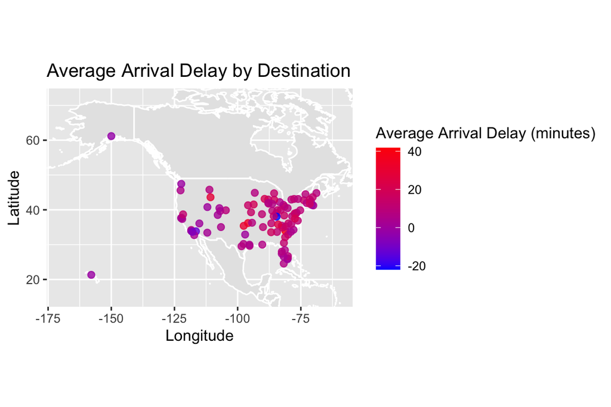

```r
ggplot() +
  geom_polygon(
    data = world_map,
    aes(
      x = long,
      y = lat,
      group = group
    ),
    fill = "gray90",
    color = "white"
  ) +
  geom_point(
    data = mapped_airports,
    aes(
      x = lon,
      y = lat,
      color = avg_arr_delay
    ),
    size = 2,
    alpha = 0.8
  ) +
  scale_color_gradient(
    low = "blue",
    high = "red"
  ) +
  coord_quickmap(
    xlim = c(-170, -60),
    ylim = c(15, 72)
  ) +
  labs(
    title = "Average Arrival Delay by Destination",
    x = "Longitude",
    y = "Latitude",
    color = "Average Arrival Delay (minutes)"
  )
```

The color scale shows average arrival delays ranging from approximately −20 to 40 minutes. Redder points represent destinations with positive average arrival delays, meaning that flights arrived later than their scheduled arrival time on average. Bluer points represent destinations with negative average arrival delays, meaning that flights arrived earlier than scheduled on average.

Most destinations are shown in purple or pink, corresponding to average arrival delays of approximately 0 to 20 minutes. A smaller number of destinations are shown in red or blue. Both red and blue points are more densely concentrated in the eastern United States, where most of the mapped destinations are located.

## Q9. Create as many plots and summary statistics as needed to answer - Which weather phenomena have the most impact on flight delays?

### 1. Precipitation and Departure Delay

```r
delay_weather <- flights_weather |>
  filter(!is.na(dep_delay))
```

```r
precip_delay_summary <- delay_weather |>
  filter(!is.na(precip)) |>
  mutate(
    precipitation = case_when(
      precip == 0 ~ "No precipitation",
      precip > 0 ~ "Precipitation"
    )
  ) |>
  group_by(precipitation) |>
  summarise(
    n_flights = n(),
    mean_dep_delay = mean(dep_delay),
    median_dep_delay = median(dep_delay)
  )

precip_delay_summary
```

```
# A tibble: 2 × 4
  precipitation    n_flights mean_dep_delay median_dep_delay
  <chr>                <int>          <dbl>            <dbl>
1 No precipitation    305907           11.4               -2
2 Precipitation        21086           30.9                5
```

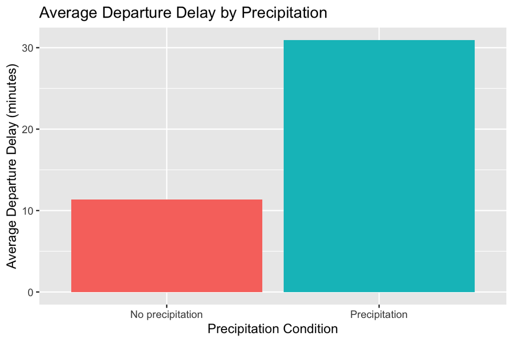

```r
ggplot(
  precip_delay_summary,
  aes(
    x = precipitation,
    y = mean_dep_delay,
    fill = precipitation
  )
) +
  geom_col() +
  labs(
    title = "Average Departure Delay by Precipitation",
    x = "Precipitation Condition",
    y = "Average Departure Delay (minutes)"
  ) +
  guides(fill = "none")
```

The summary table shows that 21,086 flights were scheduled during hours with precipitation, while 305,907 flights were scheduled during hours without precipitation. The mean departure delay was 30.9 minutes with precipitation and 11.4 minutes without precipitation. The median delays were 5 minutes and −2 minutes, respectively. Therefore, flights scheduled during precipitation had an average delay about 19.5 minutes longer. The table and barplot both show that precipitation was associated with longer departure delays.

### 2. Visibility and Departure Delay

```r
visibility_delay_summary <- delay_weather |>
  filter(!is.na(visib)) |>
  group_by(visib) |>
  summarise(
    n_flights = n(),
    mean_dep_delay = mean(dep_delay),
    median_dep_delay = median(dep_delay)
  ) |>
  arrange(visib)

visibility_delay_summary
```

```
# A tibble: 20 × 4
   visib n_flights mean_dep_delay median_dep_delay
   <dbl>     <int>          <dbl>            <dbl>
 1  0           87           32.3               -2
 2  0.06        85           22.2                0
 3  0.12       403           50.7                6
 4  0.25      1297           20.5               -1
 5  0.5       1319           32.6                2
 6  0.75       429           30.1                1
 7  1         1343           32.2                7
 8  1.25       181           53.2               18
 9  1.5       1542           25.9                2
10  1.75       132           43.3                9
11  2         2912           22.7                2
12  2.5       2285           21.2                0
13  3         3374           21.2                1
14  4         2132           19.5                0
15  5         4563           21.1                0
16  6         5944           19.8               -1
17  7         7006           19.2               -1
18  8         7314           20.0               -1
19  9        10985           18.8               -1
20 10       273660           11.0               -2
```

```r
visibility_delay_summary |>
  filter(visib %in% c(0.12, 1.25, 10))
```

```
# A tibble: 3 × 4
  visib n_flights mean_dep_delay median_dep_delay
  <dbl>     <int>          <dbl>            <dbl>
1  0.12       403           50.7                6
2  1.25       181           53.2               18
3 10       273660           11.0               -2
```

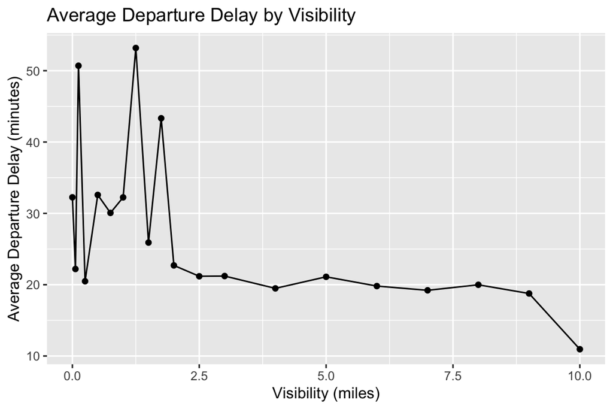

```r
ggplot(
  visibility_delay_summary,
  aes(x = visib, y = mean_dep_delay)
) +
  geom_line() +
  geom_point() +
  labs(
    title = "Average Departure Delay by Visibility",
    x = "Visibility (miles)",
    y = "Average Departure Delay (minutes)"
  )
```

The plot showed a general downward pattern, with average departure delay tending to decrease as visibility increased. However, the line moved up and down considerably at the lower visibility levels. The summary table provided the exact values for these points. At 0.12 miles of visibility, 403 flights had a mean departure delay of 50.7 minutes. At 1.25 miles, 181 flights had a mean delay of 53.2 minutes.

The table showed that 273,660 flights had 10 miles of visibility, with a mean delay of 11.0 minutes. The 10-mile visibility level had the lowest mean departure delay in the table. Because the low-visibility values were based on much smaller numbers of flights, I interpreted the individual fluctuations carefully. Taken together, the table and plot show that lower visibility was associated with longer average departure delays.

### 3. Wind Speed and Departure Delay

```r
wind_speed_delay_summary <- delay_weather |>
  filter(!is.na(wind_speed)) |>
  group_by(wind_speed) |>
  summarise(
    n_flights = n(),
    mean_dep_delay = mean(dep_delay),
    median_dep_delay = median(dep_delay)
  ) |>
  arrange(wind_speed)

wind_speed_delay_summary
```

```
# A tibble: 34 × 4
   wind_speed n_flights mean_dep_delay median_dep_delay
        <dbl>     <int>          <dbl>            <dbl>
 1       0        11711           9.98               -2
 2       3.45     11390          10.5                -2
 3       4.60     17558          10.3                -2
 4       5.75     21819           9.68               -2
 5       6.90     25717          10.8                -2
 6       8.06     28391          12.2                -2
 7       9.21     29697          11.9                -2
 8      10.4      26570          12.5                -2
 9      11.5      27306          12.0                -2
10      12.7      23922          14.0                -1
# ℹ 24 more rows
```

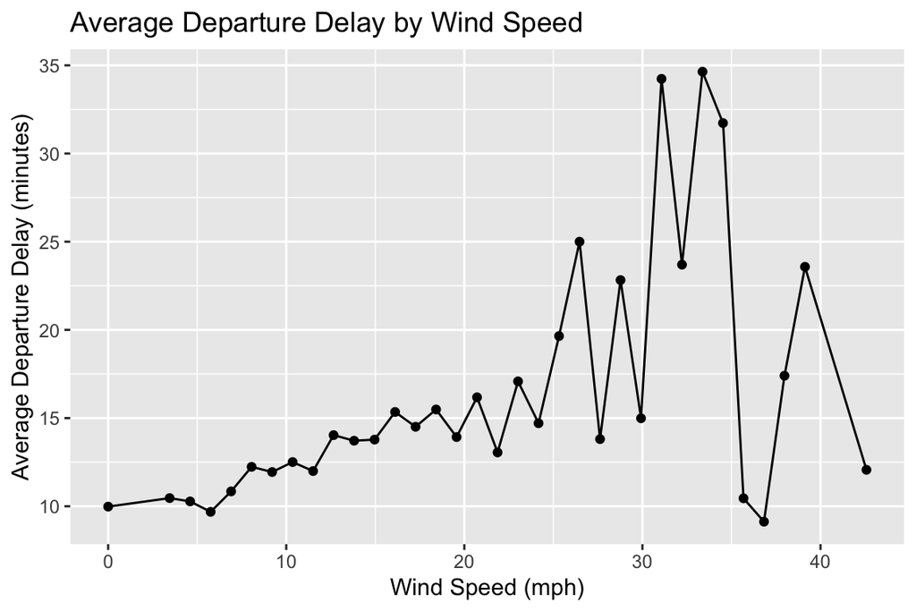

```r
ggplot(
  wind_speed_delay_summary,
  aes(x = wind_speed, y = mean_dep_delay)
) +
  geom_line() +
  geom_point() +
  labs(
    title = "Average Departure Delay by Wind Speed",
    x = "Wind Speed (mph)",
    y = "Average Departure Delay (minutes)"
  )
```

The summary table showed that the mean departure delay was 9.98 minutes at 0 mph and 14.0 minutes at 12.7 mph. The plot showed a general increase in average departure delay as wind speed increased. Between approximately 25 and 35 mph, several of the plotted mean delays were above 20 minutes. However, the line fluctuated sharply above 30 mph, showing that average delay did not increase steadily at every wind speed. Taken together, the table and plot suggest that higher wind speeds were generally associated with longer departure delays, although the pattern was inconsistent at the highest wind speeds.

### 4. Temperature and Humidity

### Temperature

```r
temperature_delay_summary <- delay_weather |>
  filter(!is.na(temp)) |>
  group_by(temp) |>
  summarise(
    n_flights = n(),
    mean_dep_delay = mean(dep_delay),
    median_dep_delay = median(dep_delay)
  ) |>
  arrange(temp)

temperature_delay_summary
```

```
# A tibble: 168 × 4
    temp n_flights mean_dep_delay median_dep_delay
   <dbl>     <int>          <dbl>            <dbl>
 1  10.9        32           6.66             -2.5
 2  12.0        71          12.3              -3
 3  12.9        97          14.6              -2
 4  13.1         6          83.5              86
 5  14         156           7.09             -2.5
 6  15.1       177           7.11             -3
 7  16.0       295          12.4              -1
 8  17.1       386          12.3              -1
 9  18.0       426          17.3              -0.5
10  19.0       525          13.4              -1
# ℹ 158 more rows
```

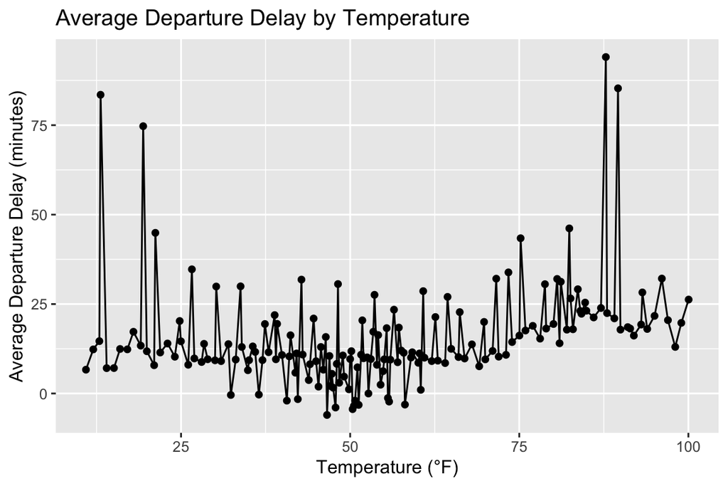

```r
ggplot(
  temperature_delay_summary,
  aes(x = temp, y = mean_dep_delay)
) +
  geom_line() +
  geom_point() +
  labs(
    title = "Average Departure Delay by Temperature",
    x = "Temperature (°F)",
    y = "Average Departure Delay (minutes)"
  )
```

The temperature plot did not show a consistent increasing or decreasing pattern with departure delay. Most temperature-specific means between approximately 30°F and 70°F were between about 0 and 25 minutes. The plot included several much higher values, but some were based on very small groups. For example, at 13.1°F, the table showed a mean delay of 83.5 minutes and a median of 86 minutes, but only six flights were included. Because this estimate was based on such a small sample, it should not be given the same weight as estimates based on many flights. After considering both the plotted pattern and the group sizes, temperature did not show a consistent association with departure delay.

### Humidity

```r
humidity_group_summary <- delay_weather |>
  filter(!is.na(humid)) |>
  mutate(
    humidity_group = case_when(
      humid < 25 ~ "0 to <25%",
      humid < 50 ~ "25 to <50%",
      humid < 75 ~ "50 to <75%",
      humid <= 100 ~ "75 to 100%"
    ),
    humidity_group = factor(
      humidity_group,
      levels = c(
        "0 to <25%",
        "25 to <50%",
        "50 to <75%",
        "75 to 100%"
      )
    )
  ) |>
  group_by(humidity_group) |>
  summarise(
    n_flights = n(),
    mean_dep_delay = mean(dep_delay),
    median_dep_delay = median(dep_delay)
  )

humidity_group_summary
```

```
# A tibble: 4 × 4
  humidity_group n_flights mean_dep_delay median_dep_delay
  <fct>              <int>          <dbl>            <dbl>
1 0 to <25%           6842          11.2                -1
2 25 to <50%        115025           8.58               -2
3 50 to <75%        124627          11.3                -2
4 75 to 100%         80482          20.6                 0
```

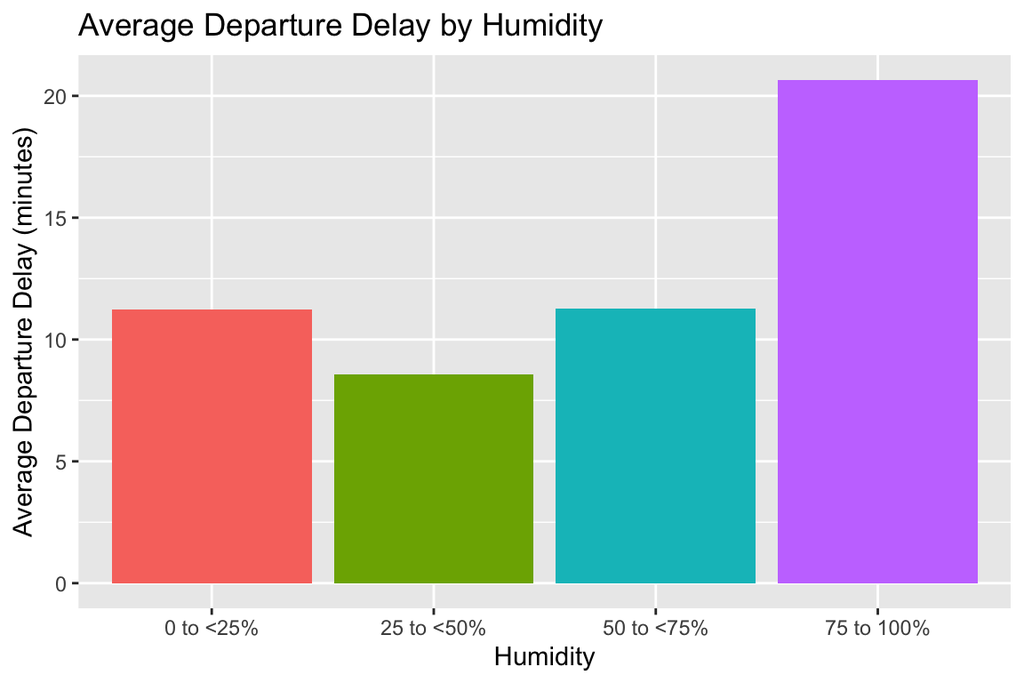

```r
ggplot(
  humidity_group_summary,
  aes(
    x = humidity_group,
    y = mean_dep_delay,
    fill = humidity_group
  )
) +
  geom_col() +
  labs(
    title = "Average Departure Delay by Humidity",
    x = "Humidity",
    y = "Average Departure Delay (minutes)"
  ) +
  guides(fill = "none")
```

The humidity summary and barplot showed that the 75% to 100% humidity group had the highest mean departure delay. This group included 80,482 flights and had a mean delay of 20.6 minutes. In comparison, the 25% to less than 50% group included 115,025 flights and had the lowest mean delay at 8.58 minutes. However, the median delays were 0 minutes and −2 minutes, a difference of only 2 minutes. The difference between the means, about 12 minutes, was much larger than the difference between the medians. This is consistent with the right-skewed delay distribution shown earlier, where a small number of long delays pulled the mean upward. Therefore, the highest-humidity group had a higher mean departure delay, while the median delays in the two groups were relatively similar.

### 5. Atmospheric Pressure and Departure Delay

```r
pressure_delay_summary <- delay_weather |>
  filter(!is.na(pressure)) |>
  group_by(pressure) |>
  summarise(
    n_flights = n(),
    mean_dep_delay = mean(dep_delay),
    median_dep_delay = median(dep_delay)
  ) |>
  arrange(pressure)

pressure_delay_summary
```

```
# A tibble: 454 × 4
   pressure n_flights mean_dep_delay median_dep_delay
      <dbl>     <int>          <dbl>            <dbl>
 1     984.         1          -6                -6
 2     985         23           4.26             -4
 3     986.        18           5.89             -1
 4     991.        14          17.7              -1.5
 5     992.        27           4.41             -1
 6     992.        26          23.6               4
 7     994.        44          15.8               0
 8     994.        18          18.4               1
 9     994.        40          16.9               0
10     994.        33          14.8              -3
# ℹ 444 more rows
```

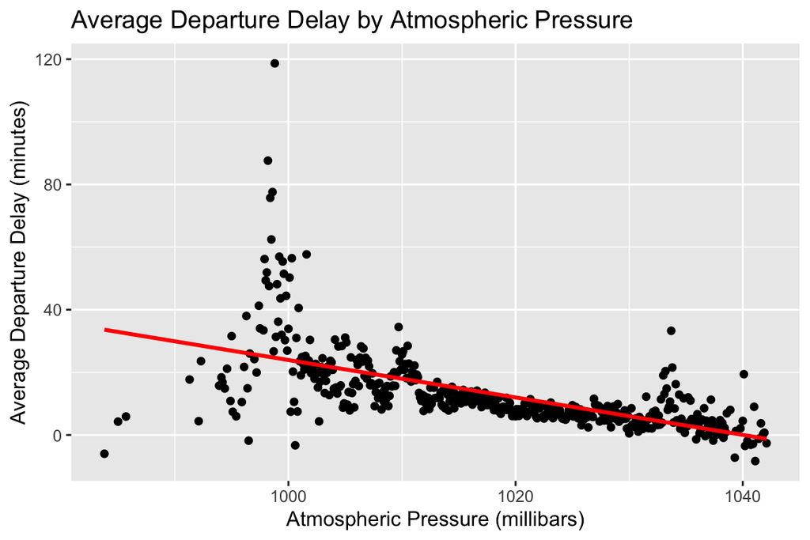

```r
ggplot(
  pressure_delay_summary,
  aes(
    x = pressure,
    y = mean_dep_delay
  )
) +
  geom_point() +
  geom_smooth(
    method = "lm",
    se = FALSE,
    color = "red"
  ) +
  labs(
    title = "Average Departure Delay by Atmospheric Pressure",
    x = "Atmospheric Pressure (millibars)",
    y = "Average Departure Delay (minutes)"
  )
```

In the scatterplot, each point represented the mean departure delay at one pressure level. The red fitted line sloped downward, showing that the mean delays generally became shorter as atmospheric pressure increased. However, the points at the lower pressure levels were widely spread out. The summary table showed that some of these pressure levels included very few flights. For example, the lowest pressure shown was approximately 984 millibars and included only one flight, so its mean delay was not a stable estimate. Overall, the plot suggests that lower pressure was associated with longer average departure delays, but the pattern was not consistent across all pressure levels.

### Conclusion

Looking across the tables and plots, precipitation and reduced visibility showed the clearest relationships with longer departure delays. Flights scheduled during hours with precipitation had a mean delay of 30.9 minutes, compared with 11.4 minutes when no precipitation was recorded. A similar pattern appeared for visibility. The mean delay was 50.7 minutes at 0.12 miles and 53.2 minutes at 1.25 miles, but only 11.0 minutes at 10 miles. High humidity was also associated with a higher mean delay. The mean was 20.6 minutes in the 75% to 100% humidity group and 8.58 minutes in the 25% to less than 50% group, although their medians were relatively close at 0 and −2 minutes. Average delay generally increased with wind speed, but the values fluctuated at higher speeds. Temperature did not show a consistent pattern, while the fitted line for pressure sloped downward with considerable variation among the lower-pressure values. Overall, precipitation and reduced visibility had the clearest observed relationships with departure delays.